# Example

The following example does some basic plotting with R.

## Basic Code Expressions

Here is an example of inline code: 2 + 2 = 4

Here is an example R codeblock with `echo=TRUE` (the default):

```r
2 + 2
```

```
## [1] 4
```

Here is the same example R codeblock but with `echo=FALSE`:

```
## [1] 4
```

Here is a sample of plotting data:

```r
head(cars)
```

```
##   speed dist
## 1     4    2
## 2     4   10
## 3     7    4
## 4     7   22
## 5     8   16
## 6     9   10
```

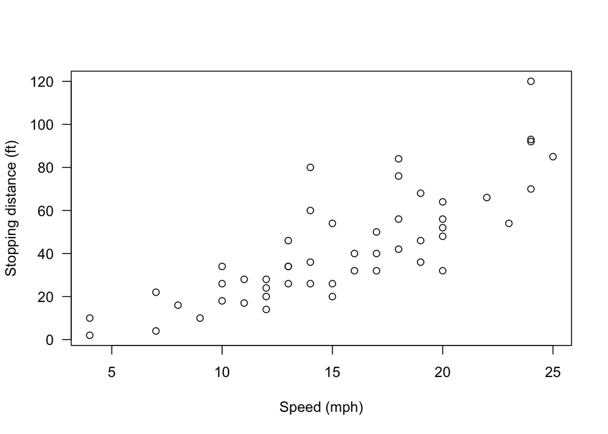

```r
plot(cars, xlab = "Speed (mph)", ylab = "Stopping distance (ft)", las = 1)
```

Finally, variables declared in one code block:

```r
x = 12
```

… can be referenced in another:

```r
x
```

```
## [1] 12
```

This allows you to explain your analysis as you build it.

## Simple Analysis Example

For the followig analysis, we want to explore the `iris` package:

```r
head(iris)
```

```
##   Sepal.Length Sepal.Width Petal.Length Petal.Width Species
## 1          5.1         3.5          1.4         0.2  setosa
## 2          4.9         3.0          1.4         0.2  setosa
## 3          4.7         3.2          1.3         0.2  setosa
## 4          4.6         3.1          1.5         0.2  setosa
## 5          5.0         3.6          1.4         0.2  setosa
## 6          5.4         3.9          1.7         0.4  setosa
```

Let’s look at a plot of the data color-coded by species:

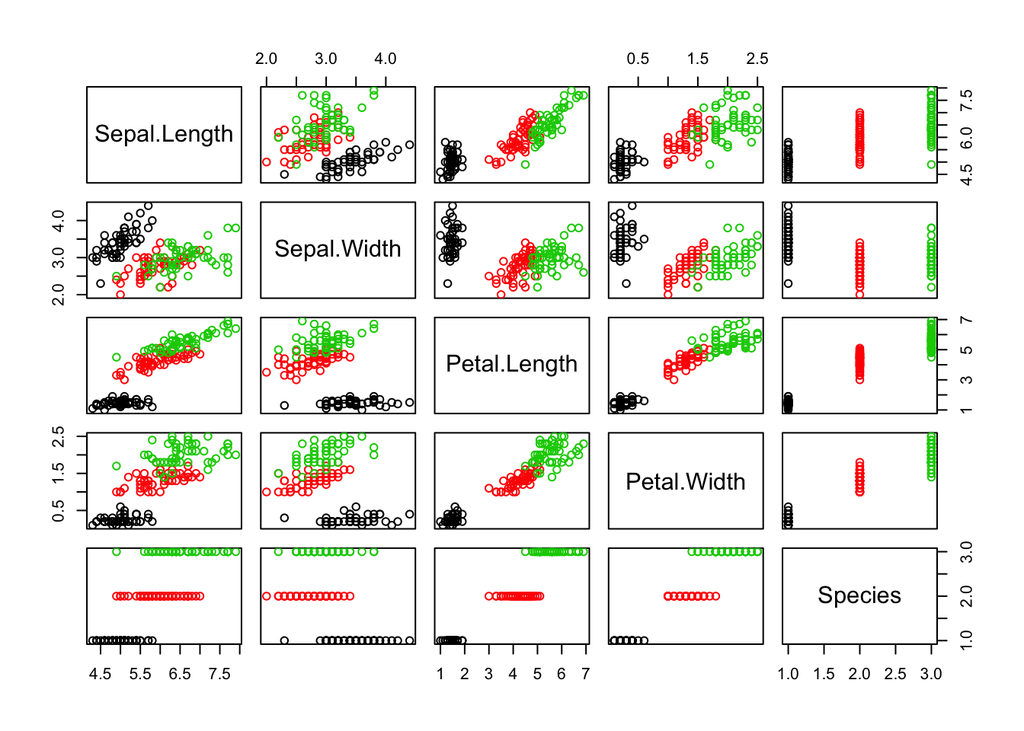

```r
plot(iris, col=iris$Species)
```

Finally, let’s look at some scatterplots of the data (taken from a [question on Stack Overflow](http://stats.stackexchange.com/questions/30788/whats-a-good-way-to-use-r-to-make-a-scatterplot-that-separates-the-data-by-trea)):

Load the `ggplot` library:

```r
library(ggplot2)
```

Using this, we can see the data clustered by species:

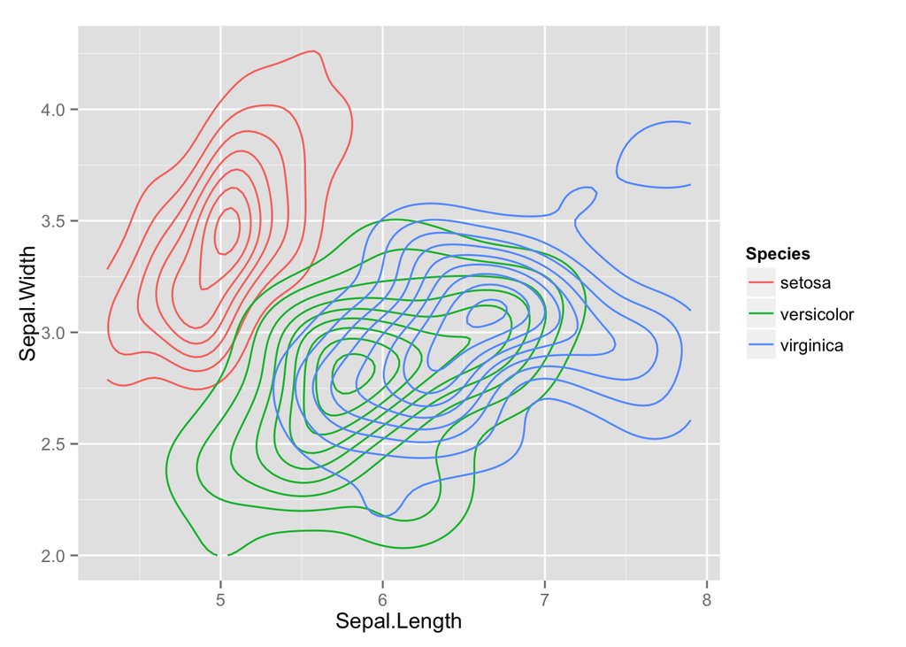

```r
ggplot(iris, aes (x=Sepal.Length, y=Sepal.Width, colour=Species)) + stat_density2d()
```

And, as a reminder, if you didn’t want your R code to be displayed when showing any part of this, you could simple include `echo=FALSE` in the `{r}` directives. This allows you to build up a complex series of instructions and just display the final output (the following is copied shamelessly from [Getting Fancy with 3-D Scatterplots](http://www.r-bloggers.com/getting-fancy-with-3-d-scatterplots/)).

Here’s a 3-D scatterplot:

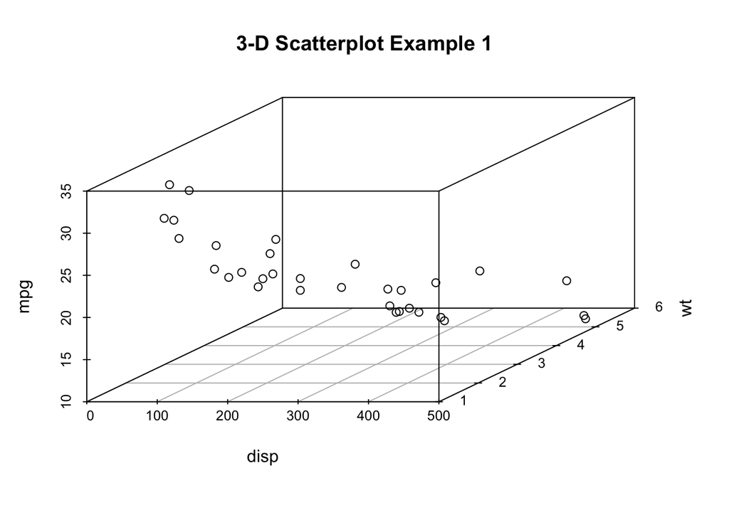

Here’s the same scatterplot with vertical lines to help visualize the (X,Y) portions of the coordinates:

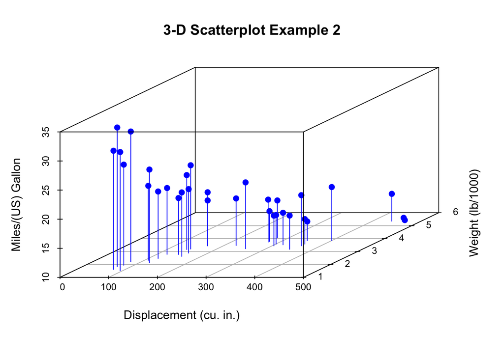

Here’s the same scatterplot with points labeled:

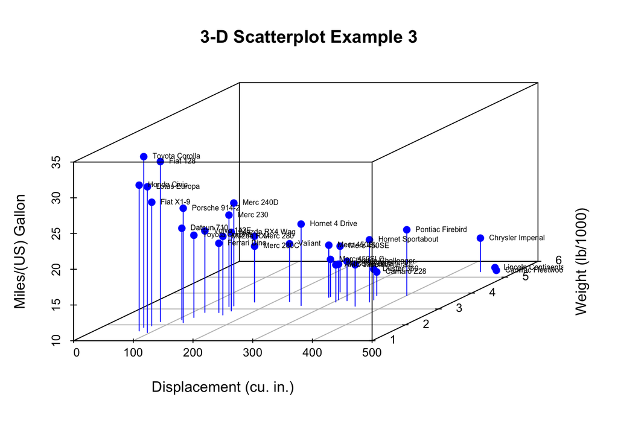

And here’s the same scatterplot with color-coding by class:

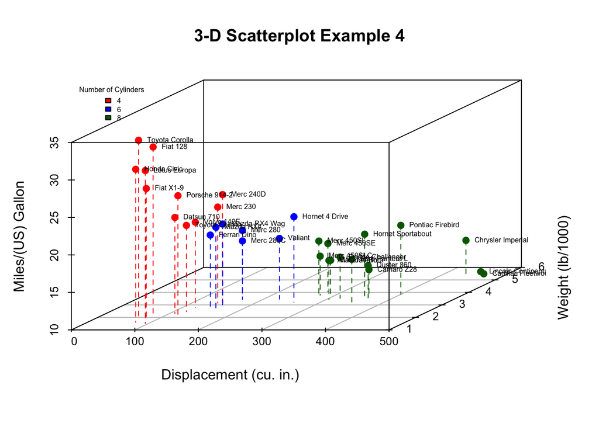

## Conclusion

The combination of R and Markdown makes for a very powerful report tool.